Statistical Spatial and Temporal Downscaling of Meteorological Data for

Water Quality Forecasting Model at Falling Creek Reservoir

Laura Puckett

Advisor: Dr. Quinn Thomas

Virginia Tech, FREC 4994: Undergraduate Research

Fall Semester 2018

Introduction

water quality at Falling Creek Reservoir, Virginia. Lab members use the GLM, a one-dimensional

hydrodynamic lake model (Hipsey et al., 2017) to make daily forecasts of water temperature and

the likelihood of lake turnover, both of which relate to the concentration and distribution of

contaminants. The lab plans to additionally forecast algae populations in the future.

The GLM requires input data for the environmental drivers of lake processes which we can

commonly measure, often continuously. These include meteorological variables such as ambient

air temperature, incoming surface shortwave and longwave radiation, average wind speed, and

relative humidity. Past site measurements and future meteorological forecasts drive the model and

forecast water temperature at the same depths at which physical samples are taken. Falling Creek

Reservoir is equipped with sensors that measure local meteorology precisely and frequently. In

contrast, the meteorological forecasts used to drive the model in simulations of the future are at a

coarse resolution, and are not specific to the study site. To maximize the success of environmental

forecasting, input data should be as accurate as possible and any uncertainties in the input data

should be quantified. The currently available meteorological forecasts do not necessarily meet

these criteria. To address this issue, I developed and implemented a workflow to spatially and

temporally downscale 16-day NOAA GEFS meteorological forecasts to the specific site, Falling

Creek reservoir.

Methods

Overview

Using site-specific observational data and coarse-scale GEFS forecasts, I calculated model

coefficients for the linear relationship between the observational and forecast data for five

meteorological variables: air temperature, relative humidity, wind speed, downward shortwave

radiation flux, and downward longwave radiation flux. I later used these relationships later to

spatially downscale forecasts. Next, I temporally downscaled the training data from 6-hourly to

hourly and calculated the total standard error resulting from the spatial and temporal downscaling

processes. The last two weeks of data were withheld from the training dataset, and I instead

downscaled forecasts over this time period. I then compared the resulting downscaled forecasts

[figure not shown]

and the original forecasts prior to downscaling to observational data to assess whether downscaling

made the forecasts more accurate.

Data

Observational data was retrieved at the minute-scale from an on-site meteorological station

established by researchers starting in late April of 2018. Table 1 shows the instruments associated

with each meteorology variable of interest. Outputs from the NOAA Global Ensemble Forecasting

System (GEFS) model were used as the meteorology forecasts. The GEFS forecasts have a spatial

resolution of 1 degree latitude by 1 degree longitude and a temporal resolution of 6 hours. Each

forecast predicts 16 days into the future and is comprised of 21 ensemble members representing

uncertainty in starting conditions. The NOAA forecast represents meteorological variables which

are fluxes, shortwave and longwave radiation, as averages over the previous 6 hours, and states

variables as predictions at 6-hour intervals. Because the least uncertainty exists at the beginning of

the 16-day forecasts, only the first 24 hours of each GEFS forecast were included in the training

dataset.

Table 1. Utilized sensor capabilities

On-Site Sensors

Meteorological variable

Precision

HC2S3 Temperature and Relative

Humidity Probe

Air Temperature at 2m

-50 - 100℃ ± 0.1

Relative Humidity at 2m

0 - 100% ± 1.3

Wind Monitor

Wind Speed at 10m

0 - 100 m/s ± 0.3

Hukseflux Net Radiation

Surface Downward Shortwave

Radiation Flux

0 - 2000 W/m² ± 10%

Surface Downward Longwave

Radiation Flux

0 - 1000 W/m² ± 10%

Parameter Fitting

I fit the model coefficients for spatial downscaling according to the linear relationship

between observational data and forecasts in the training dataset. Although meteorological variables

are required at hourly resolution for the GLM model, I started by aggregating the minute-scale

observational data and 6-hourly GEFS forecasts to the daily scale. I did this because there was a

greater signal in the relationship between observations and forecasts at the daily scale than subdaily

scale, where observational noise was high. Using linear regression, I related the observations and

forecasts for each of the meteorological variables. I applied a linear transformation to each

meteorological variable of the training data to reduce bias in the forecasts (i.e., the debias step).

[figure not shown]

After spatially debiasing, I downscaled the forecasts from daily resolution to hourly

resolution. To temporally downscale shortwave radiation, I redistributed the daily downscaled

value according to a solar geometry function (Dietze, 2017) that incorporates site-specific diel and

seasonal solar patterns. To downscale air temperature, relative humidity, and average wind speed,

I started by redistributing the spatially downscaled daily average according to the original pattern

in the original GEFS forecasts. I did this by calculating the relative difference between each

original 6-hourly NOAA forecast and the average for that day, then added that value to the spatially

debiased daily averages. I did this to retain some of the information from the sub-daily forecast

values, while still preserving the daily average of the spatially debiased values. After redistributing

to 6-hourly values, I interpolated to hourly resolution the monotone piecewise cubic interpolation

method. Unlike the other metrics, I did not downscale longwave radiation to the hourly resolution.

Because longwave radiation is a flux, not a state, the information from GEFS forecasts represents

an average of the 6-hour period. Without a known relationship to redistribute longwave across the

day, as was the case with shortwave, the 6-hourly average is insufficient information to temporally

downscale to an hourly resolution. For these reasons, longwave is left at the daily resolution at this

time. The methods of temporal downscaling are summarized in Table 2.

Table 2. Temporal Downscaling by meteorological variable

Meteorological variable

Method of temporal downscaling

Air Temperature at 2m

Interpolation

Relative Humidity at 2m

Interpolation

Wind Speed at 10m

Interpolation

Shortwave Radiation Flux

Solar Geometry

Longwave Radiation Flux

None

After downscaling the training data, I calculated the standard deviation of the residuals from linear

regression between observational data and forecast data for later use as a downscaling noise

addition term. For longwave, I calculated this after the spatial debiasing step because that was the

last step. For the other meteorological variables, I calculated this after the spatial and temporal

downscaling steps were complete. The steps for the overall parameter fitting process are

summarized (figure 1).

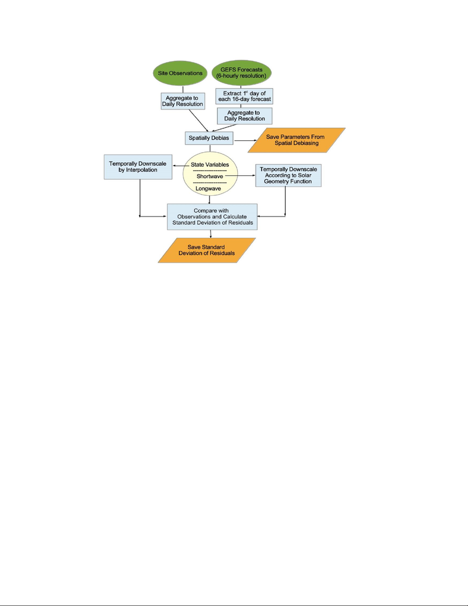

Figure 1. Flowchart of parameter-fitting steps.

Downscaling Future Forecasts

After fitting the model coefficients, I downscaled a 16-day GEFS forecast over the period

of time withheld from the training dataset, according to the following steps. As in the model fitting

process, I aggregated the forecasts to daily resolution. Then, I used the saved model coefficients

from the spatial downscaling of the training data to spatially downscale the forecasts at the daily

resolution. Next, I created a version of the ensemble members with added random noise sampled

from a normal distribution with error equal to the standard error previously calculated for each

meteorological variable. I then temporally downscaled these ensemble members according to the

methods previously described in the fitting process.

Evaluation

To evaluate the downscaling process, I compared two weeks of downscaled forecasts and

two weeks of non-downscaled forecasts against observational data. An “out-of-the-box”

implementation of the GEFS forecasts which is the current form of input in the lake water quality

forecasting served as a control to compare the downscaled forecasts against. In this “non-

downscaled” version, 6-hourly GEFS forecasts of physical states were linearly interpolated to the

hourly scale. The 6-hourly longwave and shortwave values were repeated over the preceding 6

hours that the forecast is associated with.

Next, I performed steps to evaluate the downscaling process. I calculated R

2

values for the

linear relationship between forecasts and observations to determine the strength these relationships

by variable. I calculated the average difference between downscaled forecasts and observational

[figure not shown]

data for each meteorological variable to determine average bias in downscaled forecasts. To assess

the effectiveness of the confidence interval created by forecast ensemble members, I calculated the

percentage of observations that fell within the bounds of forecasted values. I evaluated the

performance of the downscaling in these three ways using a series of 1-day forecasts spanning 14

days. I downscaled only the first day of each GEFS to evaluate the downscaling process, because

error in short-term forecasts are more reflective of the error from downscaling than long-term

forecasts, which have greater propagation of GEFS noise through time.

Results

The results are broken into four categories: (1) model parameterization (2) relatedness of

downscaled forecasts and observations, (3) the bias in the forecasts, and (4) the representation of

error in the forecasts.

Model Parameterization

The results of the parameter fitting process are shown in Table 3 below. The slope,

intercept, and R 2 of the linear spatial debiasing at the daily resolution are shown for each

meteorological variable. The R 2 for air temperature, shortwave radiation, and longwave

radiation were particularly high at the daily resolution. While the R 2 for air temperature, relative

humidity, and wind speed all decreased by more than 0.1, the R 2 for shortwave radiation

remained nearly the same after temporal downscaling. Wind speed forecasts were poorly

correlated with observations at the daily resolution and especially at after temporal downscaling

to hourly resolution. The standard deviation of residuals from downscaling shortwave radiation

were particularly high.

Table 3. Downscaling parameter fitting results

Slope

Intercept

R

2

after daily

spatial debiasing

R

2

after spatial &

temporal downscaling

Standard deviation of

residuals after downscaling

Air Temperature

0.96

13.1

0.95

0.78

3.29

Relative

Humidity

1.08

-8.3

0.62

0.51

13.1

Wind Speed

0.53

0.67

0.43

0.14

1.13

Shortwave

Radiation

0.78

6.18

0.82

0.78

129

Longwave

Radiation

1.00

26.4

0.94

NA

10.6

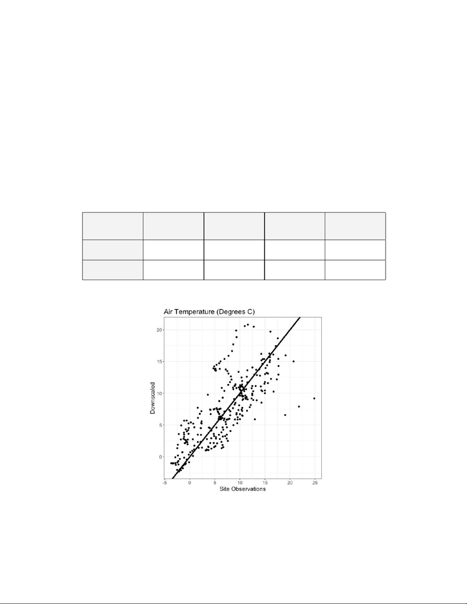

Correlation between Forecasts and Observations

The R-squared values in Table 4 describe the strength of the linear relationships between

the mean downscaled value and the site observations at each time step for two weeks of 1-day

forecasts. The “not downscaled” scenario represents the out-of-the-box implementation of the

GEFS forecasts we currently use in the GLM, while the downscaled version represents results after

spatial and temporal downscaling. Downscaling improved the correlation between forecasts and

observations for all meteorological variables except wind speed. The improvement in shortwave

radiation forecast skill was quite drastic, increasing from an R

2

of 0.19 to an R

2

of 0.88. A

scatterplot comparing the downscaled ensemble averages against the site observations is shown

(figure 3) to provide an example of a visual representation of the correlation. Scatterplots of the

remaining meteorological variables are shown in figure 1 of the appendix.

Table 4. Mean R² values of hourly comparison, first day of forecasts

Air Temperature

Shortwave

Radiation

Relative

Humidity

Wind Speed

Not downscaled

0.28

0.19

0.23

0.20

Downscaled

0.48

0.88

0.48

0.13

Figure 3. Comparison between downscaled predictions and

observations of air temperature at 2m at equal time.

[figure not shown]

Comparison of Mean Error

Another important factor when considering the performance of the downscaling process is

the bias present in the results. The average difference between forecasts and observations are

shown in Table 5 for the downscaled and “not downscaled” scenarios. A value of 0 would imply

that there is no overall bias in the forecasts, while progressively higher values indicate increased

bias. As expected, the average magnitude of bias decreased for each of the meteorological variables

to 3.9 W/m², and -34.0 W/m² to -5.6 W/m², respectively.

Table 5. Average of forecast error (forecast minus observations)

Air

Temperature

Shortwave

Radiation

Relative

Humidity

Wind Speed

Longwave

Radiation

Not downscaled

-2.44°C

25.2 W/m²

10.7%

0.48 m/s

-34.0 W/m²

Downscaled

0.64°C

3.9 W/m²

7.8%

-0.11 m/s

-5.6 W/m²

Assessment of “Confidence Intervals” of Ensembles

The last form of evaluation of the downscaling process I used was to consider the accuracy

of the confidence interval of the forecasts, or the spread between the predictions of all the ensemble

members. If the ensembles are truly representative of uncertainty in the forecasts, it would be

expected that about 90% of observations fall within the middle 90% of ensemble members, and

nearly 100% of observations would fall within the outer limits of the ensemble members. Table 6

summarizes the percentage of observations that fall within the total spread of ensemble members

while the ensemble members of shortwave radiation about 80% of the observations. All

downscaled meteorological variables improved the representation of observed conditions

compared to the non-downscaled scenario.

Table 6. Percentage of observations contained within range of ensembles

Air Temperature

Shortwave

Radiation

Relative

Humidity

Wind Speed

Longwave

Radiation

Not downscaled

18.1%

26.7%

8.5%

22.7%

17.1%

Downscaled

97.2%

82.2%

92.3%

98.8%

86.2%

The downscaled ensemble for air temperature and shortwave are shown (figure 4). The

ensemble members of temperature and shortwave both cover a relatively large range. Some

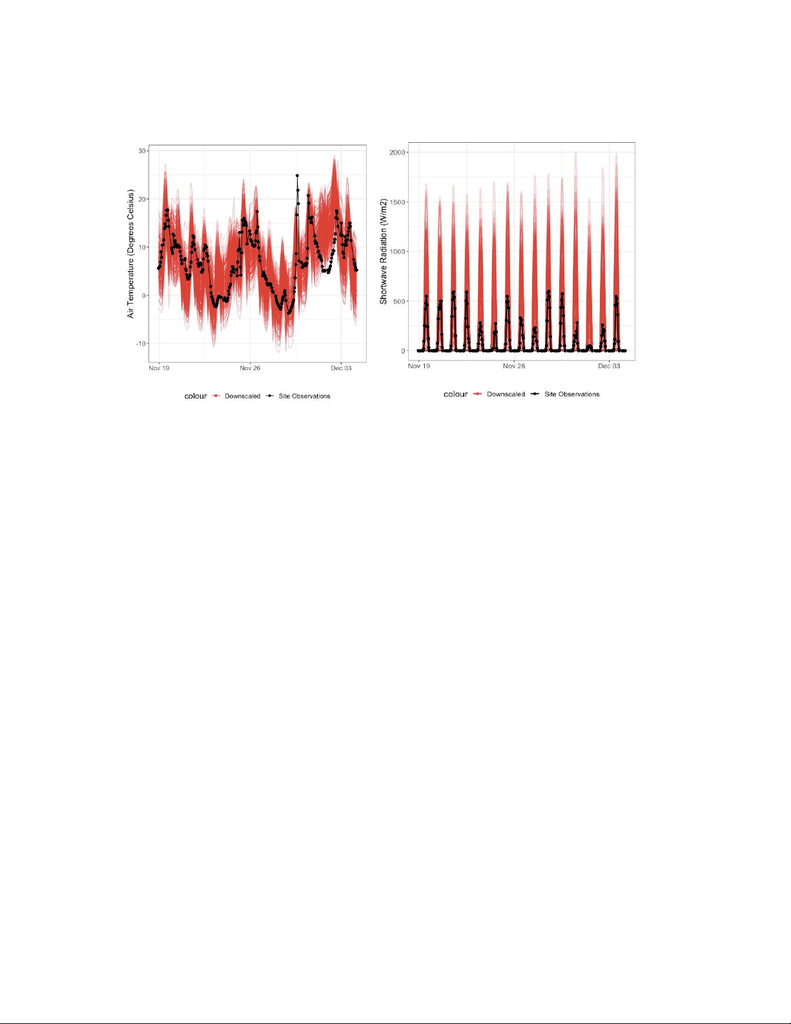

shortwave ensemble members reach values greater than 1,500 W/m² which are not feasible.

Representations of the remaining meteorological variables are shown (Appendix, figures 2-4).

Figure 4. Observed air temperature at 2 meters and 1-day predicted forecasts over a late-fall 14-

day period (left). Observed shortwave radiation flux and 1-day predicted forecasts (right).

Discussion

Overall, this downscaling process substantially improved the representation of

meteorological forecasts for use in the GLM at Falling Creek Reservoir. The correlation between

forecasts and observations was strengthened for air temperature, shortwave radiation, and relative

humidity when spatially and temporally downscaled. There was not a strong relationship between

forecasted average wind speed and downscaled average wind speed, likely because wind speed

behaves more stochastically than the other variables. The downscaling process reduced the bias in

forecasts for all variables, which an important result, because bias in the meteorological input data

could cause bias in the GLM output. The noise addition step should be refined because some

ensemble members reach unfeasible values, as is the case for shortwave radiation flux.

Now that we have developed the general workflow for the downscaling process, future

work can further improve our framework and its results. For all meteorological variables, we used

a simple linear regression for spatial downscaling. Researchers have successfully implemented

other forms of statistical downscaling in other studies such as canonical correlation analysis and

even artificial neural networks (Deka, 2017). One benefit of our approach is that it is highly

flexible, in addition to being relatively accurate. Beyond the linear model, different methods of

spatial downscaling are available, and an evaluation process can be helpful to identify what works

best for each meteorological variable.

In addition to adapting the downscaling model, we can use more informed methods of noise

addition. Currently, we add random noise independently for each meteorological variable.

However, there is known covariance between meteorological variables. For example, unexpected

cloudiness would cause a decrease in both shortwave radiation and air temperature. If we can

incorporate the covariance between meteorological variables, we could account for such

circumstances and provide ensemble members that represent more realistic variation among

meteorological variables.

While there are ideas for improvement, our downscaling process has already shown

substantial improvement over the non-downscaled option. Future work could further improve

accuracy and robustness of the downscaling process. Once integrated into the water quality

forecasting project, more analysis should be done to further quantify the effect of downscaling

meteorology forecasts in the water quality forecasting framework.

References

Deka, B. (2017). Statistical downscaling of daily and hourly climate scenarios for the various

meteorological variables at Montreal. (Master’s thesis). Montreal: McGill University.

Dietze, M. (2017). Prediction in ecology: a first principles framework. Ecological Applications,

27(7), 2048-2060. https://doi.org/10.1002/eap.1589

Hipsey R. M., Bruce L.C., Boon C., et al., (2017). A General Lake Model (GLM 2.4) for linking

with high-frequency sensor data from the Global Lake Ecological Observatory Network

(GLEON). Geosci. Model Dev. Discuss. Manuscript in review.

https://doi.org/10.5194/gmd-2017-257

Hugh, R. (2002). Statistical Downscaling of Daily Temperature in Central Europe. American

Meteorological Society. 15, 1731-1742.

https://doi.org/10.1175/1520-0442(2002)015<1731:SDODTI>2.0.CO;2

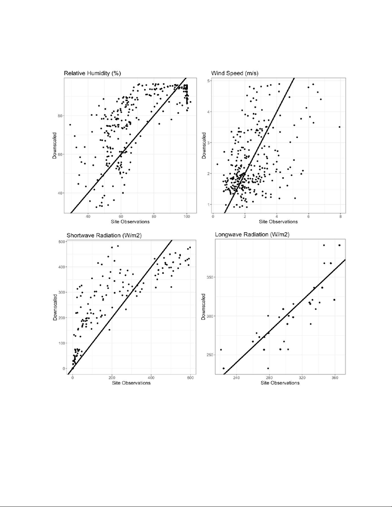

Appendix

Figure 1. Comparison between downscaled predictions and

observations of additional meteorological variables at equal time.

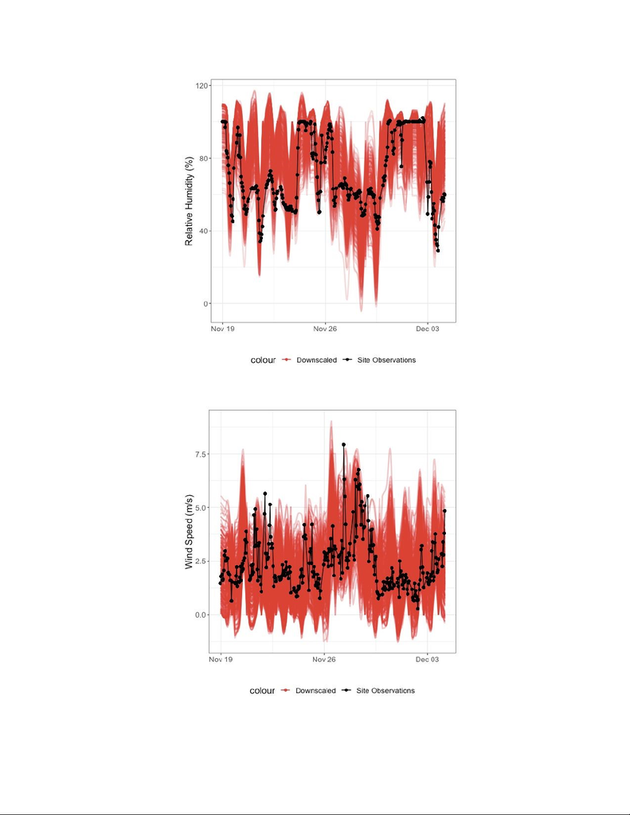

Figure 2. Observed relative humidity at 2 meters and 1-day predicted forecasts.

Figure 3. Observed wind speed at 10 meters and 1-day predicted forecasts.

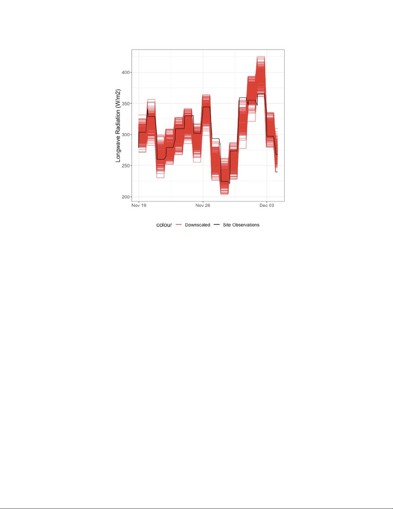

Figure 4. Observed longwave radiation flux and 1-day predicted forecasts.

Git Repository:

https://github.com/EcoDynForecast/NOAA_download_downscale